# Sentiment Analysis Demo

Bodo Winter

6/6/2019

## Preliminaries:

Let’s load in packages and data:

```r
library(tidyverse)
library(tidytext)
library(sentimentr)
```

```r
library(broom)
library(wordcloud)
yelp <- read_csv('yelp_review_subset.csv')
yelp
```

```
## # A tibble: 10,000 x 9
##    review_id user_id business_id stars date       text  useful funny  cool
##    <chr>     <chr>   <chr>       <int> <date>     <chr>  <int> <int> <int>
##  1 GQFbfIkS… 9Q4DDf… S9ufhGRada…     5 2016-05-19 My f…      0     0     0
##  2 tLA7km4G… 3H7-iH… Gvj_nneJoA…     5 2010-02-01 "Suc…      3     0     0
##  3 5SSFQ68D… qMhjVL… TkSUCMtrb4…     1 2016-06-05 "I r…      4     0     2
##  4 tiDJdjBF… m-wIh1… 8yYDM0s1w7…     1 2016-08-08 Rude…      5     0     0
##  5 BAgVukoS… D4M-u9… kosTPb88O4…     5 2012-04-06 Exce…      0     0     0
##  6 LfO-NqRD… DnuG7T… frC66U_YIZ…     2 2013-05-17 Habe…      0     0     0
##  7 T-FNsNYR… VNYmMD… c1siAPW4kx…     1 2016-02-25 "I r…      2     2     2
##  8 vkBpqgSK… ujISM2… uChTCA6MsL…     4 2013-09-01 This…      0     0     0
##  9 5RWhv3wf… R5usoA… vdloJPM3bS…     5 2014-11-08 Exce…      0     0     0
## 10 e7WVftlh… _vZmA3… JpBx7K0z5P…     5 2015-07-25 Orde…      0     0     0
## # ... with 9,990 more rows
```

Let’s get rid of variables that we are not interested in for now:

```r
yelp <- select(yelp, -user_id, -business_id, -date,
                -useful, -funny, -cool)
yelp
```

```
## # A tibble: 10,000 x 3
##    review_id              stars text
##    <chr>                  <int> <chr>
##  1 GQFbfIkSyDcXA_vCcyQoxQ     5 My family does an annual Vegas trip each …
##  2 tLA7km4GJ79UE3tZkgCJzA     5 "Such a great place to get away and do wo…
##  3 5SSFQ68D_PhWD18Ve5t8XQ     1 "I really regret letting my 73 year old m…
##  4 tiDJdjBFuRL69INaHipCzg     1 Rude staff. Small tight spaces. Really ba…
##  5 BAgVukoSlHTl9J4XVnhH5w     5 Excellent service, excellent food.  You m…
##  6 LfO-NqRDmeVx3IyATDV_xg     2 Habe heute über Lieferheld bei Viet Quan …
##  7 T-FNsNYRZUgNMLr0ILbLqw     1 "I regularly visit a business in the shop…
##  8 vkBpqgSKTvw-kmDRQHeu8w     4 This place is soooooooooooo yum!! One dow…
##  9 5RWhv3wfLKOWl90GB8BhKA     5 Excellent beer, food, location and staff.…
## 10 e7WVftlhuCFzMrbu0ZLocQ     5 Ordered a simple pepperoni pizza and some…
## # ... with 9,990 more rows
```

Using the tidytext workflow, let’s tokenize all the texts, but keeping the review_id and stars as index information:

```r
tokens <- yelp %>% unnest_tokens(word, text)
tokens
```

```
## # A tibble: 1,133,728 x 3
##    review_id              stars word
##    <chr>                  <int> <chr>
##  1 GQFbfIkSyDcXA_vCcyQoxQ     5 my
##  2 GQFbfIkSyDcXA_vCcyQoxQ     5 family
##  3 GQFbfIkSyDcXA_vCcyQoxQ     5 does
##  4 GQFbfIkSyDcXA_vCcyQoxQ     5 an
##  5 GQFbfIkSyDcXA_vCcyQoxQ     5 annual
##  6 GQFbfIkSyDcXA_vCcyQoxQ     5 vegas
##  7 GQFbfIkSyDcXA_vCcyQoxQ     5 trip
##  8 GQFbfIkSyDcXA_vCcyQoxQ     5 each
##  9 GQFbfIkSyDcXA_vCcyQoxQ     5 april
## 10 GQFbfIkSyDcXA_vCcyQoxQ     5 and
## # ... with 1,133,718 more rows
```

Let’s get rid of “stop words”, that is, function words, highly frequent adverbials etc.

```r
data("stop_words") # comes with tidytext
tokens <- anti_join(tokens, stop_words)
tokens
```

```
## # A tibble: 405,133 x 3
##    review_id              stars word
##    <chr>                  <int> <chr>
##  1 GQFbfIkSyDcXA_vCcyQoxQ     5 family
##  2 GQFbfIkSyDcXA_vCcyQoxQ     5 annual
##  3 GQFbfIkSyDcXA_vCcyQoxQ     5 vegas
##  4 GQFbfIkSyDcXA_vCcyQoxQ     5 trip
##  5 GQFbfIkSyDcXA_vCcyQoxQ     5 april
##  6 GQFbfIkSyDcXA_vCcyQoxQ     5 dos
##  7 GQFbfIkSyDcXA_vCcyQoxQ     5 break
##  8 GQFbfIkSyDcXA_vCcyQoxQ     5 table
##  9 GQFbfIkSyDcXA_vCcyQoxQ     5 games
## 10 GQFbfIkSyDcXA_vCcyQoxQ     5 slots
## # ... with 405,123 more rows
```

Let’s make word clouds of the five-star reviews…

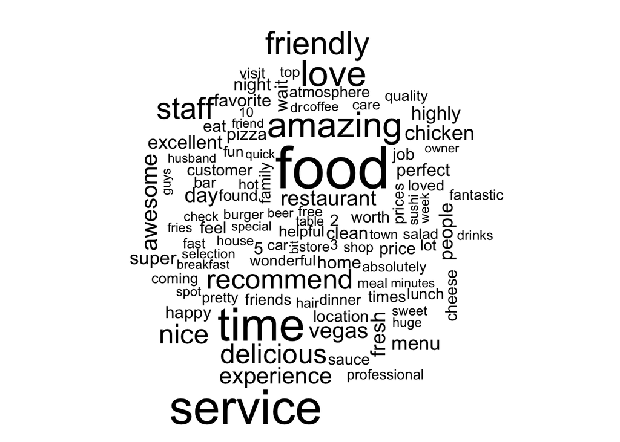

```r
tokens %>%
  filter(stars == 5) %>%
  count(word, sort = TRUE) %>%
  filter(n > 50) %>%
  with(wordcloud(word, n, max.words = 100))
```

… and one of the one-star reviews:

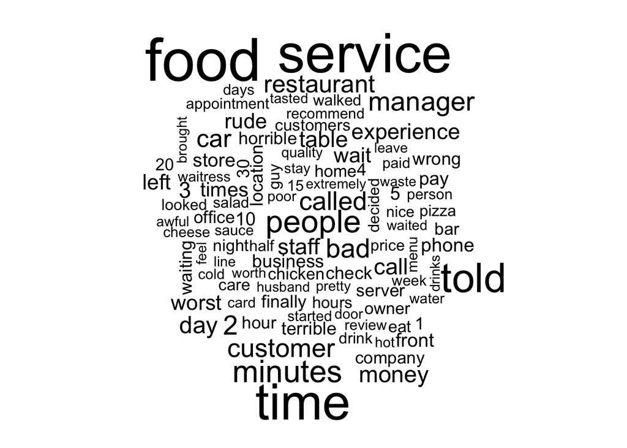

```r
tokens %>%
  filter(stars == 1) %>%
  count(word, sort = TRUE) %>%
  filter(n > 50) %>%
  with(wordcloud(word, n, max.words = 100))
```

Let’s compute average star ratings per words:

```r
avg_star <- tokens %>% group_by(word) %>%
  summarize(stars = mean(stars))
```

```r
avg_star <- tokens %>% count(word) %>%
  right_join(avg_star) %>% arrange(desc(n))
```

Let’s take only words that occurred at least 10 times (this is a pretty arbitrary threshold, you may want to think of a better one):

```r
avg_star <- avg_star %>% filter(n >= 10)
nrow(avg_star)
```

```
## [1] 5085
```

We are left with ~5000 some words.

Let’s look at those words that occur in reviews with really high or low average review stars:

```r
arrange(avg_star, stars)
```

```
## # A tibble: 5,085 x 3
##    word               n stars
##    <chr>          <int> <dbl>
##  1 screws            10  1.2
##  2 scam              20  1.25
##  3 refund            64  1.33
##  4 unprofessional    60  1.33
##  5 disgusted         11  1.36
##  6 shady             21  1.38
##  7 lied              18  1.39
##  8 visa              10  1.4
##  9 lab               19  1.42
## 10 yelled            14  1.43
## # ... with 5,075 more rows
```

Makes sense — these are all pretty bad word. “visa” is an interesting one…

```r
arrange(avg_star, desc(stars))
```

```
## # A tibble: 5,085 x 3
##    word          n stars
##    <chr>     <int> <dbl>
##  1 tattoo       21  5
##  2 airsoft      12  5
##  3 exercises    11  5
##  4 jeep         11  5
##  5 nate         11  5
##  6 brittany     10  5
##  7 flawless     10  5
##  8 propane      10  5
##  9 painless     17  4.94
## 10 jennifer     15  4.93
## # ... with 5,075 more rows
```

Let’s see whether these star ratings correlate with emotional valence ratings that were collected in isolation (“norms”), using the data from Warriner et al. (2013):

```r
war <- read_csv('warriner_2013_cleaned.csv')
avg_star <- left_join(avg_star, war, by = c('word' = 'Word'))
```

Make a plot of this relationship:

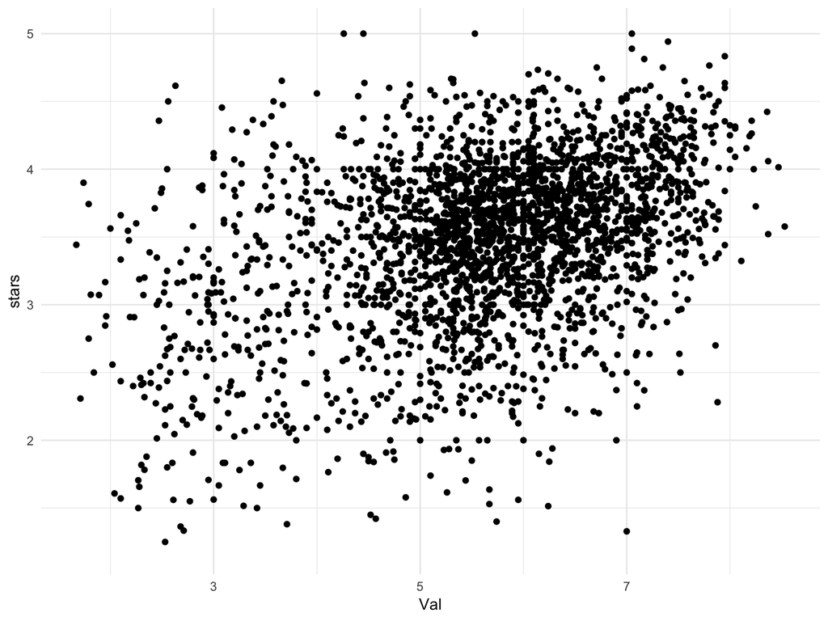

```r
avg_star %>% ggplot(aes(x = Val, y = stars)) +
  geom_point() +
  theme_minimal()
```

How strong is this correlation?

```r
with(avg_star, cor(Val, stars, use = 'complete.obs'))
```

```
## [1] 0.4037077
```

r = 0.4 … I’d say that’s pretty decent!

## Average N pos/neg words per review:

For this, let’s use a standard sentiment lexicon, the Bing et al. one… this is pretty coarse. It’s relatively small and has a categorical scheme (positive / negative). While that may not correspond to your theory of emotional valence (which may be continuous), dealing with words that are treated as EITHER positive OR negative is sometimes useful for presentatinal purporses.

```r
bing <- get_sentiments('bing')
```

Join this with the tokens data frame:

```r
bingtokens <- inner_join(tokens, bing)
bingtokens
```

```
## # A tibble: 64,277 x 4
##    review_id              stars word      sentiment
##    <chr>                  <int> <chr>     <chr>
##  1 GQFbfIkSyDcXA_vCcyQoxQ     5 break     negative
##  2 GQFbfIkSyDcXA_vCcyQoxQ     5 fun       positive
##  3 GQFbfIkSyDcXA_vCcyQoxQ     5 friendly  positive
##  4 GQFbfIkSyDcXA_vCcyQoxQ     5 fun       positive
##  5 GQFbfIkSyDcXA_vCcyQoxQ     5 honest    positive
##  6 GQFbfIkSyDcXA_vCcyQoxQ     5 enjoyed   positive
##  7 GQFbfIkSyDcXA_vCcyQoxQ     5 hilarious positive
##  8 GQFbfIkSyDcXA_vCcyQoxQ     5 enjoyed   positive
##  9 GQFbfIkSyDcXA_vCcyQoxQ     5 recommend positive
## 10 GQFbfIkSyDcXA_vCcyQoxQ     5 bonus     positive
## # ... with 64,267 more rows
```

Let’s compute the number of positive and negative words per review:

```r
pos_per_review <- bingtokens %>%
  count(review_id, index = sentiment) %>%
  spread(index, n, fill = 0)
```

Let’s calculate the total number of evaluative words and exclude those for which we have less than 5 words (not much to say there). Let’s also compute the proportion of positive words for each review:

```r
pos_per_review <- pos_per_review %>%
  mutate(sum = negative + positive,
         prop = positive / sum) %>%
  filter(sum >= 5)
```

Let’s get the stars from the main table in there:

```r
pos_per_review <- yelp %>%
  select(-text) %>%
  right_join(pos_per_review)
```

Let’s see how well the proportion of positive to negative words predicts the restaurant review ratings:

```r
mymdl <- lm(stars ~ prop, data = pos_per_review)
glance(mymdl)
```

```
##   r.squared adj.r.squared   sigma statistic p.value df    logLik      AIC
## 1 0.4418118     0.4417087 1.06555  4286.029       0  2 -8029.321 16064.64
##        BIC deviance df.residual
## 1 16084.43 6148.174        5415
```

An r-squared of 0.44 … that’s pretty high!

What’s the correlation coefficient then?

```r
with(pos_per_review, cor(stars, prop))
```

```
## [1] 0.6646892
```

r = 0.66 … that’s pretty high!

## Using the sentimentr package

Get reviews at the sentence level and perform the sentiment function from the sentimentr package on it. This takes amplifiers and negators into account (see description of algorithm in the sentimentr readme).

Let’s check that this works:

```r
sentiment(c('This is good', 'This is not good', 'This is very good', 'This is really good','This is excellent'))
```

```
##    element_id sentence_id word_count  sentiment
## 1:          1           1          3  0.4330127
## 2:          2           1          4 -0.3750000
## 3:          3           1          4  0.6750000
## 4:          4           1          4  0.6750000
## 5:          5           1          3  0.5773503
```

“Not good correctly receives a negative sentiment, and”very good" and “really good” are treated as better than “good”. Also, “excellent” is better than “good”, which intuitively makes sense.

```r
sentences <- get_sentences(yelp$text)
mysent <- sentiment(sentences)
mysent
```

```
##        element_id sentence_id word_count  sentiment
##     1:          1           1         18 0.00000000
##     2:          1           2         10 0.07905694
##     3:          1           3         13 0.00000000
##     4:          1           4          4 0.40000000
##     5:          1           5         12 0.14433757
##    ---
## 84035:      10000           1         14 0.40089186
## 84036:      10000           2         21 0.22912878
## 84037:      10000           3         16 0.46250000
## 84038:      10000           4         26 0.29417420
## 84039:      10000           5          6 0.30618622
```

To compare this to the Yelp reviews stars, we want to average the sentence-level sentiments by review.

```r
myavgs <- mysent %>% group_by(element_id) %>%
  summarize(sentiment = mean(sentiment, na.rm = TRUE))
```

Append this to the main tibble:

```r
yelp <- bind_cols(yelp, myavgs)
```

See whether they are correlated:

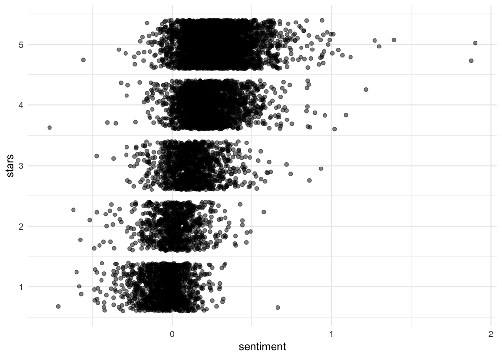

```r
yelp %>% ggplot(aes(x = sentiment, y = stars)) +
  geom_jitter(alpha = 0.5, width = 0) +
  theme_minimal()
```

Use sentiment to predict stars:

```r
with(yelp, cor(sentiment, stars))
```

```
## [1] 0.6096696
```

```r
mymdl <- lm(stars ~ sentiment, data = yelp)
glance(mymdl)
```

```
##   r.squared adj.r.squared    sigma statistic p.value df    logLik      AIC
## 1  0.371697     0.3716341 1.136639  5914.704       0  2 -15469.14 30944.29
##        BIC deviance df.residual
## 1 30965.92  12916.9        9998
```

Interestingly, we don’t get too much extra leverage out of this sophisticated algorithm.